# Cherry Blossom 10-Mile Race Report

Akshata Jha, Breanna Neuwirth, and Andrin Zuellig

December 13, 2024

##### Introduction

The primary question in this consulting project is: How does age influence athletic performance in the Cherry Blossom 10-Mile Race? The goal is to provide a clear and simple answer to understand how age and other factors impact race performance. With the help of our client we were able to scrape around 400,000 observations from the Race Data website into a dataframe which then gave us a lot of data to analyze for trends.

##### Background

The Cherry Blossom 10-Mile Race began as a small local event in Washington, D.C., designed to bring the community together for a fun and challenging experience. Over time, it has grown into a renowned annual event, attracting thousands of runners from across the country and around the world. Its rich history, spanning five decades, provides us a dataset with thousands of entries to explore long-term trends in athletic performance. Age plays a notable role in endurance races, with performance generally peaking in early adulthood and gradually decreasing with age. This project seeks to analyze how age affects race performance and identify key trends over time.

##### Data

The dataset for this project contains over 400,000 race observations spanning more than 50 years of the Cherry Blossom 10-Mile Race. It includes detailed participant-level data with the following variables:

Name: Name of the participant. PiD_TiD: Rank within their division. PiS_TiS: Rank position within their gender Age: Age of the participant during the race. Time: Official finish time of the participant. Pace: Average pace per mile during the race. Division: Age and gender category of the participant (e.g., M0119 = Male, ages 0-19). Hometown: Participant’s hometown (some entries are missing). Year: Year in which the race took place. Gender: Gender of the participant (M = Male, W = Female).

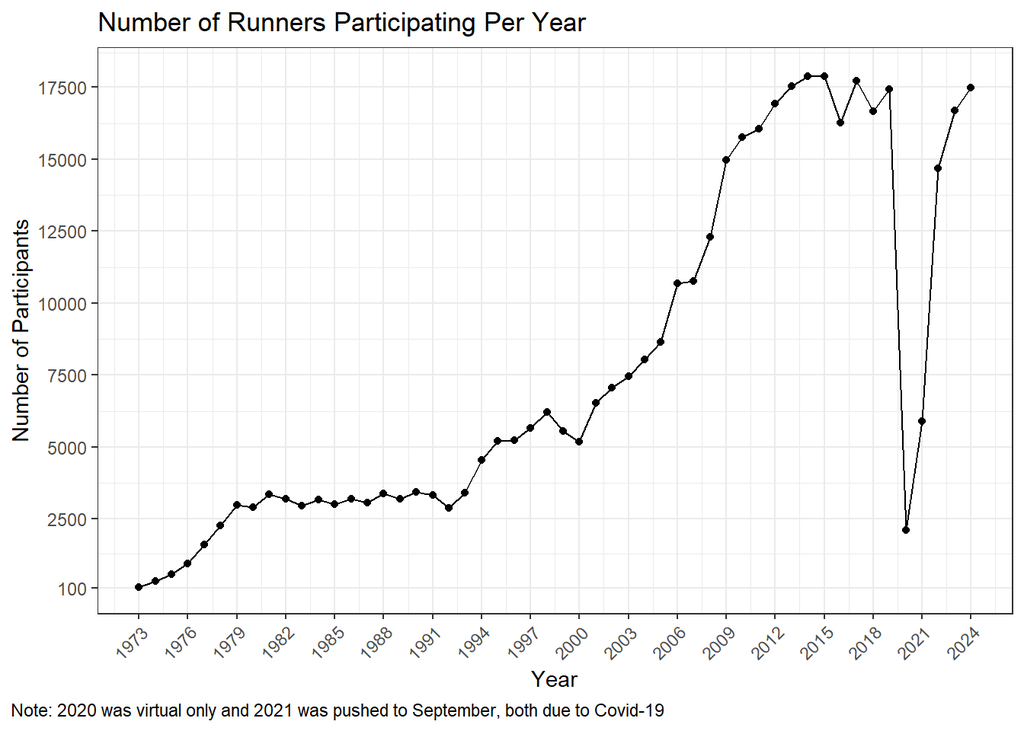

```r
graph1 <- Dat_Comb1 %>%
  group_by(Year) %>%
  add_count() %>%
  ungroup()

graph1 %>%  ggplot(aes(x=Year, y=n)) +
  geom_point() +
  geom_line() +
  scale_x_continuous(trans="identity", limits=c(1973,2024), breaks=seq(1973,2024,3)) +
  scale_y_continuous(trans="identity", limits=c(100,18000),
                     breaks=c(100, 2500,5000,7500,10000,12500,15000,17500)) +
  labs(y="Number of Participants", title="Number of Runners Participating Per Year",
       caption="Note: 2020 was virtual only and 2021 was pushed to September, both due to Covid-19") +
  theme_bw() +
  theme(plot.caption.position = "plot",
        plot.caption = element_text(hjust = 0),
       axis.text.x=element_text(angle = 45, hjust = 1))
```

```r
pander(fav_stats(graph1$n))
```

| min | Q1 | median | Q3 | max | mean | sd | n | missing |
| --- | --- | --- | --- | --- | --- | --- | --- | --- |
| 127 | 6530 | 15763 | 17434 | 17880 | 12356 | 5604 | 404306 | 0 |

Here we can see the number of participants over the years of the race. The first year of the race, 1973, had the smallest group of runners at 127 people. The peak number of runners, 17,880, took place in 2015. The race has become more popular over the years, attracting thousands of people.

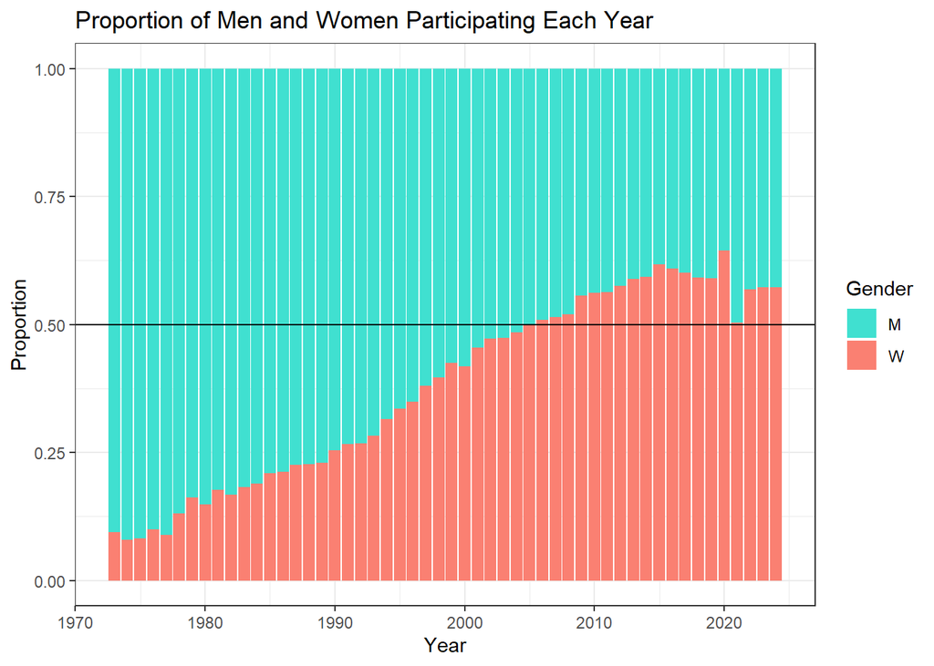

```r
Dat_Comb1 %>%
  filter(!is.na(Gender)) %>%
  ggplot(aes(x=Year, fill=Gender)) +
  geom_bar(position="fill") +
  scale_fill_manual(values = c("M" = "turquoise", "W" = "salmon")) +
  labs(y="Proportion", title = "Proportion of Men and Women Participating Each Year") +
  geom_abline(aes(intercept=0.5, slope=0), color="black") +
  theme_bw()
```

```r
graph2 <- Dat_Comb1 %>%
  group_by(Year, Gender) %>%
  add_count() %>%
  ungroup()

pander(favstats(n ~ Gender, data=graph2))
```

| Gender | min | Q1 | median | Q3 | max | mean | sd | n | missing |
| --- | --- | --- | --- | --- | --- | --- | --- | --- | --- |
| M | 115 | 3105 | 5904 | 7009 | 7483 | 5096 | 2000 | 203085 | 0 |
| W | 12 | 5435 | 9563 | 10290 | 11042 | 7731 | 3280 | 201199 | 0 |

Here we can see the proportion of men and women who have participated in the race over the years. The number of women participating has steadily increased, with recent years have more women than men running. The race organizers have been making efforts to bring popularity to the women’s division of the race, which have been working. The average number of women running in the race is 7,731 and the average for men participating is 5,096.

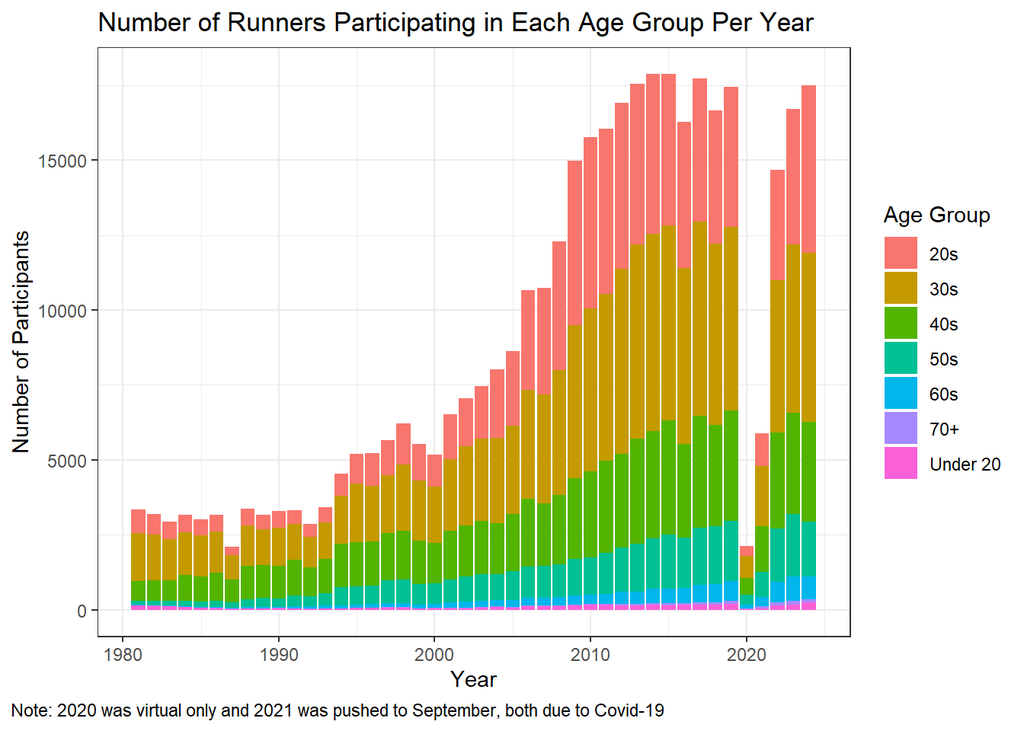

```r
graph3 <- Dat_Comb %>%
  mutate(Age_Group = case_when(
      Age < 20 ~ "Under 20",
      Age >= 20 & Age < 30 ~ "20s",
      Age >= 30 & Age < 40 ~ "30s",
      Age >= 40 & Age < 50 ~ "40s",
      Age >= 50 & Age < 60 ~ "50s",
      Age >= 60 & Age < 70 ~ "60s",
      Age >= 70 ~ "70+"))

graph3 %>% ggplot(aes(x=Year, fill=Age_Group)) +
  geom_bar(position = "stack") +
  labs(y="Number of Participants",
       title="Number of Runners Participating in Each Age Group Per Year",
       caption = "Note: 2020 was virtual only and 2021 was pushed to September, both due to Covid-19", fill="Age Group") +
  theme_bw() +
  theme(plot.caption.position = "plot",
        plot.caption = element_text(hjust = 0))
```

```r
pander(favstats(Dat_Comb1$Age))
```

| min | Q1 | median | Q3 | max | mean | sd | n | missing |
| --- | --- | --- | --- | --- | --- | --- | --- | --- |
| 2 | 29 | 35 | 43 | 91 | 36.77 | 10.54 | 400633 | 3673 |

Here we can see the number of participants for different age groups across the years of the race. The majority of runners are in their 20s and 30s. There is no age restriction for the race, so the range is rather large from 2 years old to 91 years old. The average age is about 36 years old.

##### Data Collection and Challenges

This dataset was collected by scraping results from the Cherry Blossom Race website. While the client provided some guidance, the scraping process was a difficult process as the website was not designed for easy data extraction. The data was collected in multiple files, each covering a different time period, and required extensive cleaning and preprocessing to make it suitable for analysis. The data was then combined into a single dataframe for further analysis.

##### Data Cleaning and Preprocessing

After collecting the data, the following steps were taken to clean and prepare it for analysis:

Handling Missing Values: We had a lot of columns with missing values, we had to decide whether to drop them or fill them with a value. Changing variable type: Columns such as Time and Pace were converted into numeric formats so they were easier to work with. Removing Outliers: Implausible race times or paces (e.g., unrealistically fast finish times) were identified and excluded. Removing Early Years: There were issues with the data in the first few years of the race, along with much smaller amounts of data, so we decided to remove the years 1973-1980.

#### Appendices

##### Appendix 1: Data and Data Cleaning Code

This adds the precipitation and minimum temperature for that date

```r
#library(readr)
weather <- read_csv("3865927.csv", show_col_types = F)

dates <- data.frame(
  year = 1981:2024,
  date = as.Date(c("1981-04-05", "1982-04-04", "1983-04-03", "1984-04-01",
                   "1985-03-31", "1986-04-06", "1987-04-05", "1988-04-03",
                   "1989-04-02", "1990-04-01", "1991-03-31", "1992-04-05",
                   "1993-04-04", "1994-04-03", "1995-04-02", "1996-03-31",
                   "1997-04-06", "1998-04-05", "1999-04-04", "2000-04-02",
                   "2001-04-01", "2002-04-07", "2003-04-06", "2004-04-04",
                   "2005-04-03", "2006-04-02", "2007-04-01", "2008-04-06",
                   "2009-04-05", "2010-04-04", "2011-04-03", "2012-04-01",
                   "2013-04-07", "2014-04-06", "2015-04-05", "2016-04-03",
                   "2017-04-02", "2018-04-07", "2019-04-06", "2020-04-05",
                   "2021-09-12", "2022-04-03", "2023-04-02", "2024-04-6")))

temp<-left_join(Dat_Comb, dates, by = c("Year" = "year"))
sample_n(temp, 10)
```

```
## # A tibble: 10 × 13
##    Name    PiD_TiD PiS_TiS   Age Time       Pace  Division Hometown  Year Gender
##    <chr>   <chr>   <chr>   <dbl> <Period>   <chr> <chr>    <chr>    <dbl> <chr>
##  1 Carol … 84/169  443/869    36 1H 25M 10S 8:31  W3539    Pittsbu…  1990 W
##  2 Kichel… 1532 /… 8108 /…    32 2H 13M 2S  13:18 W3034    Washing…  2022 W
##  3 Marvin… 1/131   295/71…    65 1H 3M 39S  6:22  M6569    Mclean,…  2019 M
##  4 Wesley… 145/10… 880/59…    33 1H 12M 58S 7:18  M3034    Germant…  2008 M
##  5 Allen … 267/494 1897/3…    29 1H 23M 43S 8:22  M2529    Baltimo…  1998 M
##  6 Dennis… 97/1150 388/59…    28 1H 7M 16S  6:44  M2529    Washing…  2008 M
##  7 Tyler … 192/378 1117/2…    27 1H 23M 25S 8:21  M2529    Washing…  2021 M
##  8 Jeni R… 1079 /… 4349 /…    25 1H 39M 16S 09:56 W2529    Rockvil…  2023 W
##  9 Matthe… 100/109 3322/3…    22 1H 42M 12S 10:13 M2024    Arlingt…  2002 M
## 10 Erica … 2013/2… 6336/9…    27 1H 46M 43S 10:40 W2529    Arlingt…  2011 W
## # ℹ 3 more variables: Minutes <dbl>, Pace_Num <dbl>, date <date>
```

```r
Dat_Comb.weather <- left_join(temp, select(weather, DATE, PRCP, TMIN), by = c("date" = "DATE"))
```

#### Appendix 3: Gender Insights Code

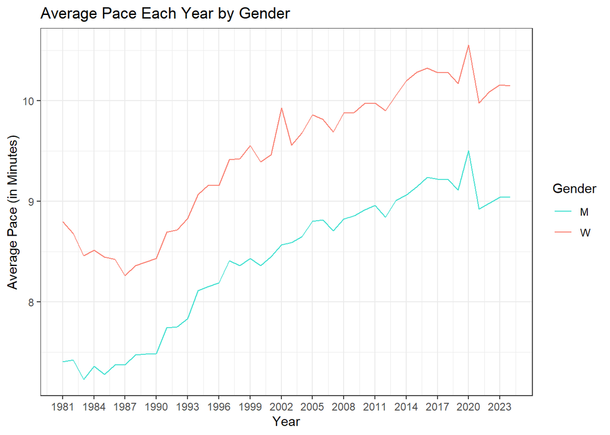

```r
graph4 <- Dat_Comb %>%
  summarise(avg_pace = mean(Pace_Num), .by=c(Gender, Year)) %>%
  ungroup()

graph4 %>% ggplot(aes(y=avg_pace, x=Year, color=Gender)) +
  geom_line() +
  scale_color_manual(values = c("M" = "turquoise", "W" = "salmon")) +
  scale_x_continuous(trans="identity", limits=c(1981,2024), breaks=seq(1981,2024,3)) +
  labs(y="Average Pace (in Minutes)", title = "Average Pace Each Year by Gender") +
  theme_bw()
```

```r
pander(favstats(avg_pace ~ Gender, data=graph4))
```

| Gender | min | Q1 | median | Q3 | max | mean | sd | n | missing |
| --- | --- | --- | --- | --- | --- | --- | --- | --- | --- |
| M | 7.234 | 7.753 | 8.579 | 8.968 | 9.504 | 8.404 | 0.6805 | 44 | 0 |
| W | 8.264 | 8.778 | 9.62 | 9.997 | 10.56 | 9.462 | 0.6894 | 44 | 0 |

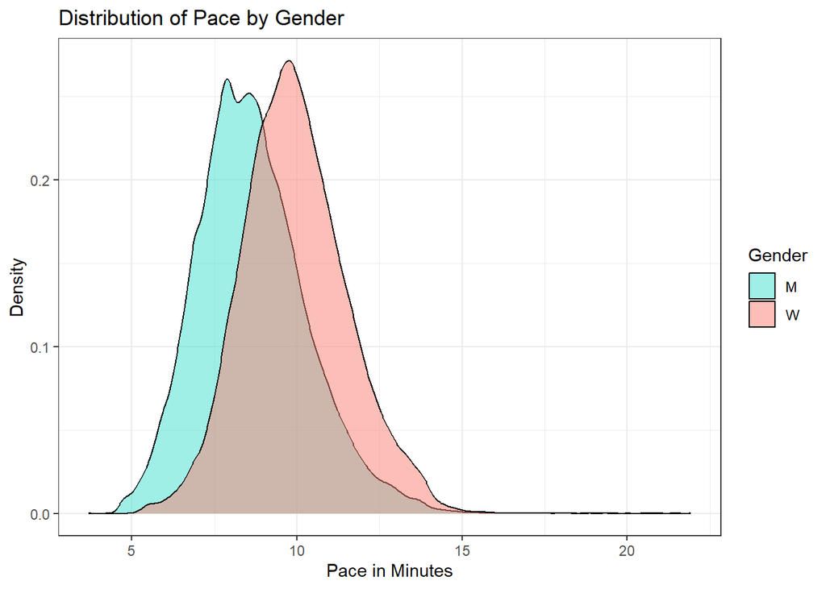

```r
Dat_Comb %>%
  ggplot(aes(x=Pace_Num, group=Gender, fill=Gender)) +
  geom_density(alpha=0.5) +
  scale_fill_manual(values = c("M" = "turquoise", "W" = "salmon")) +
  theme_bw() +
  labs(x="Pace in Minutes", title="Distribution of Pace by Gender", y="Density")
```

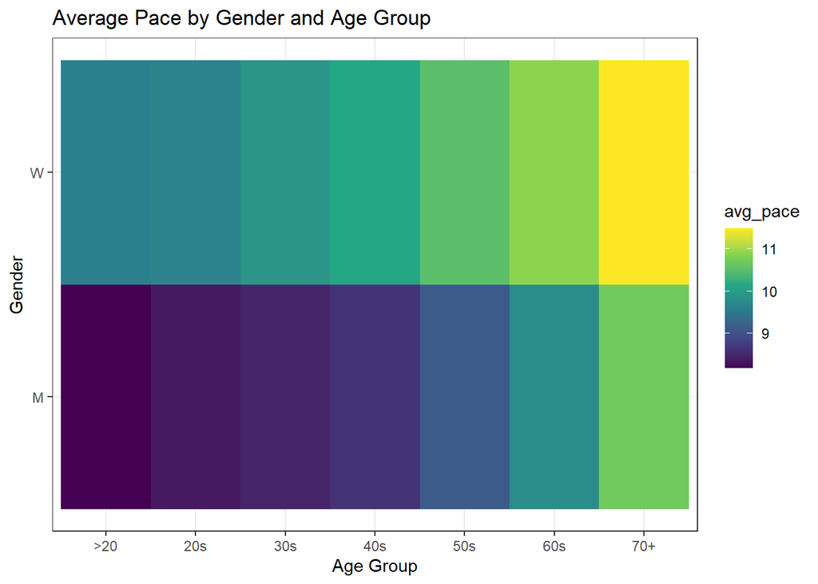

```r
Dat_Comb %>%
   mutate(Age_Group = case_when(
      Age < 20 ~ ">20",
      Age >= 20 & Age < 30 ~ "20s",
      Age >= 30 & Age < 40 ~ "30s",
      Age >= 40 & Age < 50 ~ "40s",
      Age >= 50 & Age < 60 ~ "50s",
      Age >= 60 & Age < 70 ~ "60s",
      Age >= 70 ~ "70+")) %>%
  summarise(avg_pace = mean(Pace_Num), .by=c(Gender, Age_Group)) %>%
  ungroup() %>%
  ggplot(aes(x=Age_Group, y=Gender, fill=avg_pace)) +
  geom_tile() +
  labs(x="Age Group", legend="Average Pace", title="Average Pace by Gender and Age Group") +
  theme_bw() +
  scale_fill_viridis_c()
```

## Was Runners Performance Affected by Weather?

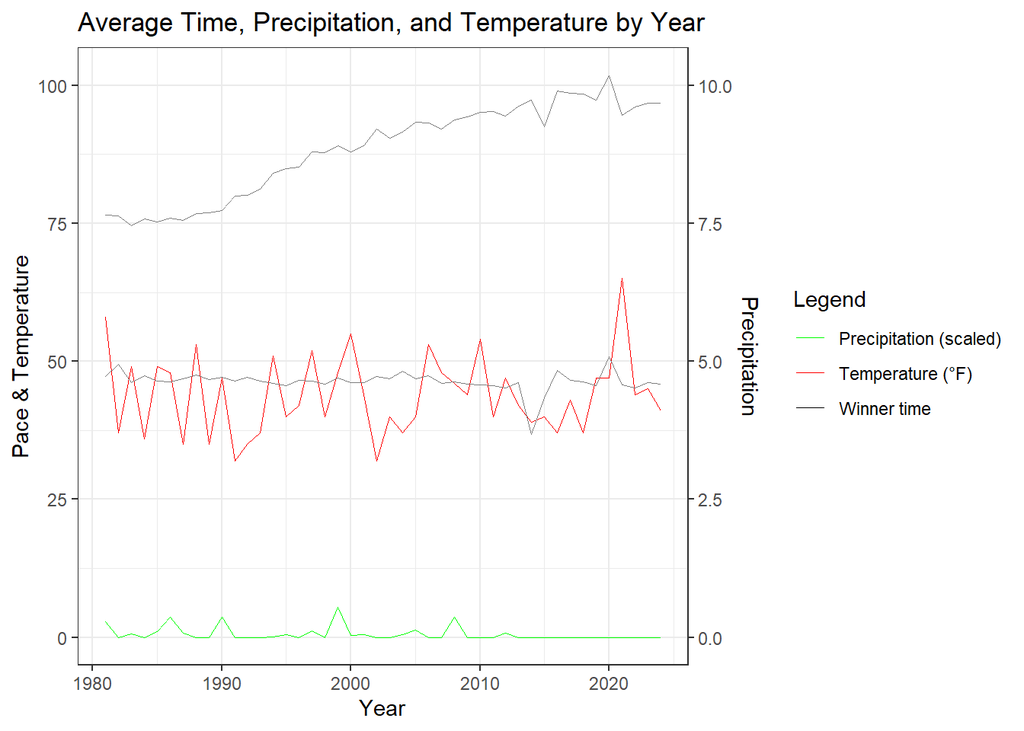

```r
avg_per_year <- Dat_Comb.weather %>%
  group_by(Year) %>%
  summarise(
    Avg_PRCP = mean(PRCP, na.rm = TRUE),
    winner=min(Minutes, na.rm = TRUE),
    Temperature = mean(TMIN, na.rm = TRUE),
    Minutes = mean(Minutes, na.rm = TRUE)
  )

# Adjusted Plot
ggplot(avg_per_year, aes(x = Year)) +
  # Line for Avg_Pace
  geom_line(aes(y = Minutes, color = "Average Pace (min)"), size = .3) +
  # Line for Avg_PRCP
  geom_line(aes(y = Avg_PRCP * 10, color = "Precipitation (scaled)"), size = 0.3) +
  # Line for Temperature
  geom_line(aes(y = Temperature, color = "Temperature (°F)"), size = 0.3) +
  # Line for Winner time
  geom_line(aes(y = winner, color = "Winner time"), size = 0.3) +
  # Primary and secondary y-axis
  geom_line(aes(y=winner, color="Winner"), size=0.3) +
  scale_y_continuous(
    name = "Pace & Temperature",
    sec.axis = sec_axis(~ . / 10, name = "Precipitation")
  ) +
  # Custom color legend
  scale_color_manual(
    name = "Legend",
    values = c(
      "Precipitation (scaled)" = "green",
      "Temperature (°F)" = "red",
      "Winner time" = "black"
    )
  ) +
  labs(
    title = "Precipitation, Temperature, and Winner Time by Year",
      "Average Pace (min)" = "blue",
      "Precipitation (scaled)" = "green",
      "Temperature (°F)" = "red",
      "Winner Time" = "black"
  ) +
  labs(
    title = "Average Time, Precipitation, and Temperature by Year",
    x = "Year"
  ) +
  theme_bw()
```

## Regression

```r
mod1 <- lm(Minutes ~ Age, data=Dat_Comb)
summary(mod1)
```

```
##
## Call:
## lm(formula = Minutes ~ Age, data = Dat_Comb)
##
## Residuals:
##     Min      1Q  Median      3Q     Max
## -53.136 -12.078  -0.677  11.073 126.842
##
## Coefficients:
##              Estimate Std. Error t value Pr(>|t|)
## (Intercept) 85.825202   0.099526  862.34   <2e-16 ***
## Age          0.186089   0.002595   71.72   <2e-16 ***
## ---
## Signif. codes:  0 '***' 0.001 '**' 0.01 '*' 0.05 '.' 0.1 ' ' 1
##
## Residual standard error: 17.11 on 391325 degrees of freedom
## Multiple R-squared:  0.01297,    Adjusted R-squared:  0.01297
## F-statistic:  5143 on 1 and 391325 DF,  p-value: < 2.2e-16
```

```r
mod2 <- lm(Minutes ~ Age + Gender, data=Dat_Comb)
summary(mod2)
```

```
##
## Call:
## lm(formula = Minutes ~ Age + Gender, data = Dat_Comb)
##
## Residuals:
##     Min      1Q  Median      3Q     Max
## -58.249 -10.865  -1.079   9.703 120.041
##
## Coefficients:
##              Estimate Std. Error t value Pr(>|t|)
## (Intercept) 74.204124   0.100228   740.4   <2e-16 ***
## Age          0.306707   0.002413   127.1   <2e-16 ***
## GenderW     14.080224   0.050863   276.8   <2e-16 ***
## ---
## Signif. codes:  0 '***' 0.001 '**' 0.01 '*' 0.05 '.' 0.1 ' ' 1
##
## Residual standard error: 15.64 on 391324 degrees of freedom
## Multiple R-squared:  0.1746, Adjusted R-squared:  0.1746
## F-statistic: 4.139e+04 on 2 and 391324 DF,  p-value: < 2.2e-16
```

```r
mod3 <- lm(Minutes ~ Age*Gender, data=Dat_Comb)
summary(mod3)
```

```
##
## Call:
## lm(formula = Minutes ~ Age * Gender, data = Dat_Comb)
##
## Residuals:
##     Min      1Q  Median      3Q     Max
## -58.348 -10.866  -1.082   9.706 120.048
##
## Coefficients:
##              Estimate Std. Error t value Pr(>|t|)
## (Intercept) 73.948496   0.132661 557.425  < 2e-16 ***
## Age          0.313292   0.003291  95.188  < 2e-16 ***
## GenderW     14.603558   0.185055  78.915  < 2e-16 ***
## Age:GenderW -0.014231   0.004839  -2.941  0.00327 **
## ---
## Signif. codes:  0 '***' 0.001 '**' 0.01 '*' 0.05 '.' 0.1 ' ' 1
##
## Residual standard error: 15.64 on 391323 degrees of freedom
## Multiple R-squared:  0.1746, Adjusted R-squared:  0.1746
## F-statistic: 2.76e+04 on 3 and 391323 DF,  p-value: < 2.2e-16
```

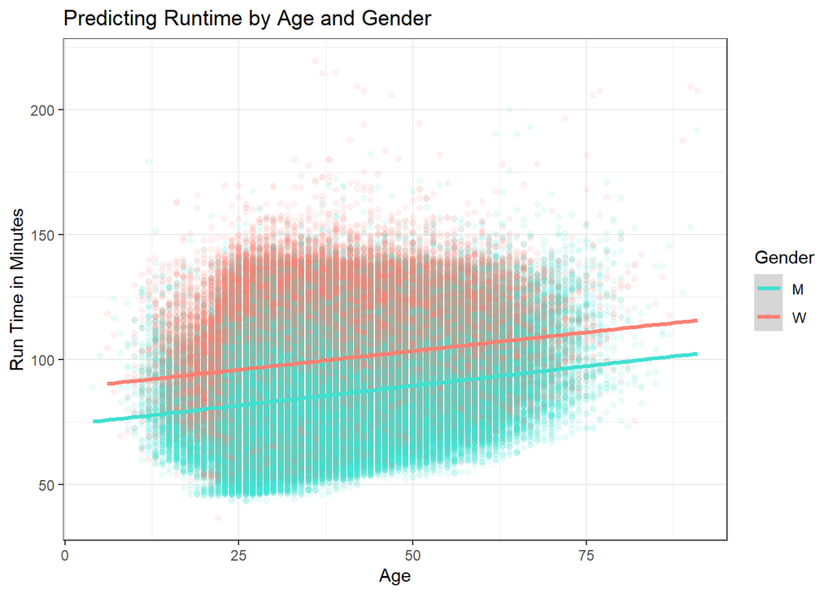

```r
#plot(mod3)

Dat_Comb %>%
  ggplot(aes(x=Age, y=Minutes, color=Gender)) +
  geom_point(alpha=0.1) +
  geom_smooth(method=lm, linewidth=1.2) +
  scale_color_manual(values = c("M" = "turquoise", "W" = "salmon")) +
  labs(y="Run Time in Minutes", title="Predicting Runtime by Age and Gender") +
  theme_bw()
```

```r
# Step 1: Filter top 20 runners per year
top_runners <- Dat_Comb.weather %>%
  group_by(Year) %>%
  arrange(Minutes) %>%
  slice_head(n = 50) %>%
  ungroup()

# Step 2: Calculate average running time, temperature, and precipitation
avg_running_time <- top_runners %>%
  group_by(Year) %>%
  summarize(
    AvgTime = mean(Minutes, na.rm = TRUE),
    AvgTemp = mean(TMIN, na.rm = TRUE),
    AvgPrecip = mean(PRCP, na.rm = TRUE)
  )

# Step 3: Detrend running time to account for overall improvement over the years
lm_trend <- lm(AvgTime ~ Year, data = avg_running_time)
avg_running_time <- avg_running_time %>%
  mutate(DetrendedTime = resid(lm_trend))
summary(lm_trend)
```

```
##
## Call:
## lm(formula = AvgTime ~ Year, data = avg_running_time)
##
## Residuals:
##     Min      1Q  Median      3Q     Max
## -3.6193 -1.1076 -0.1760  0.7372 12.9387
##
## Coefficients:
##              Estimate Std. Error t value Pr(>|t|)
## (Intercept) -12.85659   55.68918  -0.231    0.819
## Year          0.03199    0.02781   1.150    0.256
##
## Residual standard error: 2.342 on 42 degrees of freedom
## Multiple R-squared:  0.03055,    Adjusted R-squared:  0.007468
## F-statistic: 1.324 on 1 and 42 DF,  p-value: 0.2565
```

```r
# Step 4: Perform correlation analysis
cor_matrix <- avg_running_time %>%
  select(DetrendedTime, AvgTemp, AvgPrecip) %>%
  cor(use = "complete.obs")

print("Correlation Matrix:")
```

```
## [1] "Correlation Matrix:"
```

```r
print(cor_matrix)
```

```
##               DetrendedTime     AvgTemp  AvgPrecip
## DetrendedTime    1.00000000 -0.02184304 0.01166729
## AvgTemp         -0.02184304  1.00000000 0.26622083
## AvgPrecip        0.01166729  0.26622083 1.00000000
```

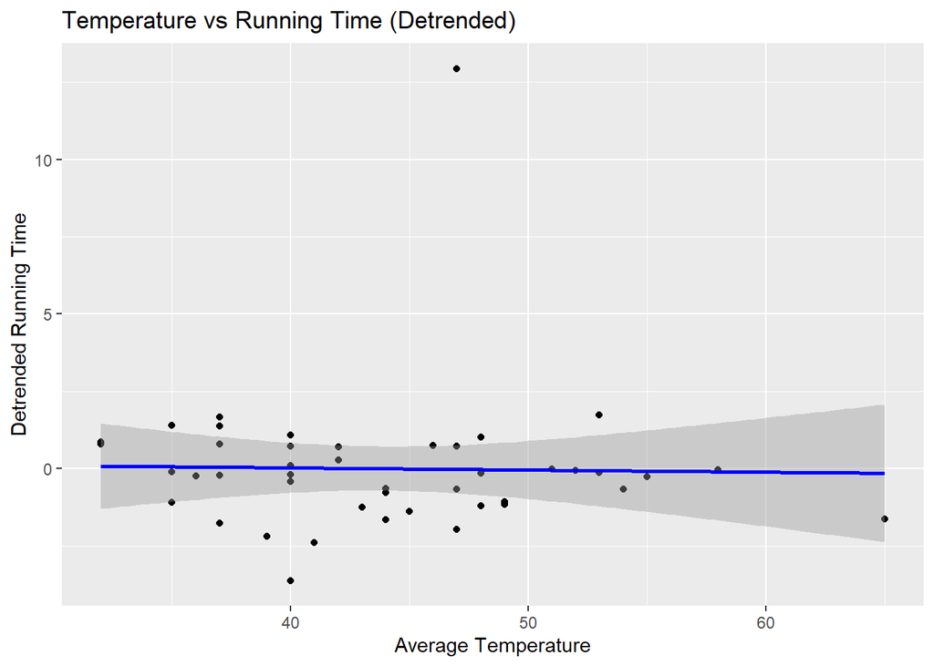

```r
# Step 5: Visualization of relationships
# Temperature vs Detrended Running Time
ggplot(avg_running_time, aes(x = AvgTemp, y = DetrendedTime)) +
  geom_point() +
  geom_smooth(method = "lm", col = "blue") +
  labs(title = "Temperature vs Running Time (Detrended)",
       x = "Average Temperature",
       y = "Detrended Running Time")
```

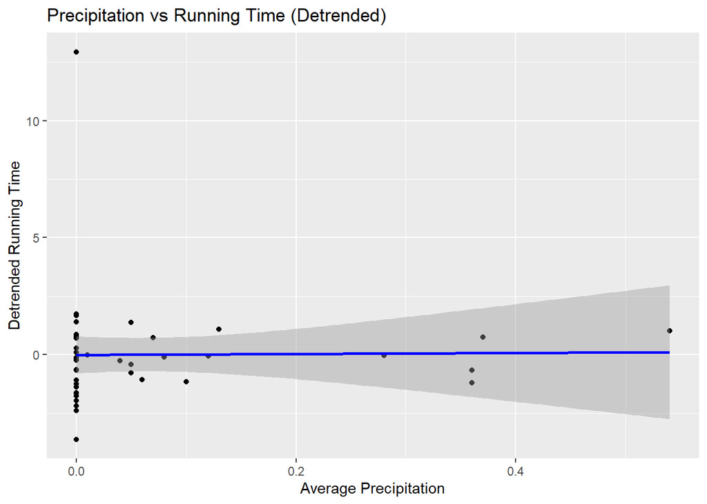

```r
# Precipitation vs Detrended Running Time
ggplot(avg_running_time, aes(x = AvgPrecip, y = DetrendedTime)) +
  geom_point() +
  geom_smooth(method = "lm", col = "blue") +
  labs(title = "Precipitation vs Running Time (Detrended)",
       x = "Average Precipitation",
       y = "Detrended Running Time")
```

```r
# Step 6: Linear regression analysis
lm_weather <- lm(DetrendedTime ~ AvgTemp + AvgPrecip, data = avg_running_time)
summary(lm_weather)
```

```
##
## Call:
## lm(formula = DetrendedTime ~ AvgTemp + AvgPrecip, data = avg_running_time)
##
## Residuals:
##     Min      1Q  Median      3Q     Max
## -3.6315 -1.1382 -0.1751  0.7123 12.9867
##
## Coefficients:
##              Estimate Std. Error t value Pr(>|t|)
## (Intercept)  0.355926   2.261270   0.157    0.876
## AvgTemp     -0.008593   0.051827  -0.166    0.869
## AvgPrecip    0.349098   3.004812   0.116    0.908
##
## Residual standard error: 2.37 on 41 degrees of freedom
## Multiple R-squared:  0.0008061,  Adjusted R-squared:  -0.04794
## F-statistic: 0.01654 on 2 and 41 DF,  p-value: 0.9836
```

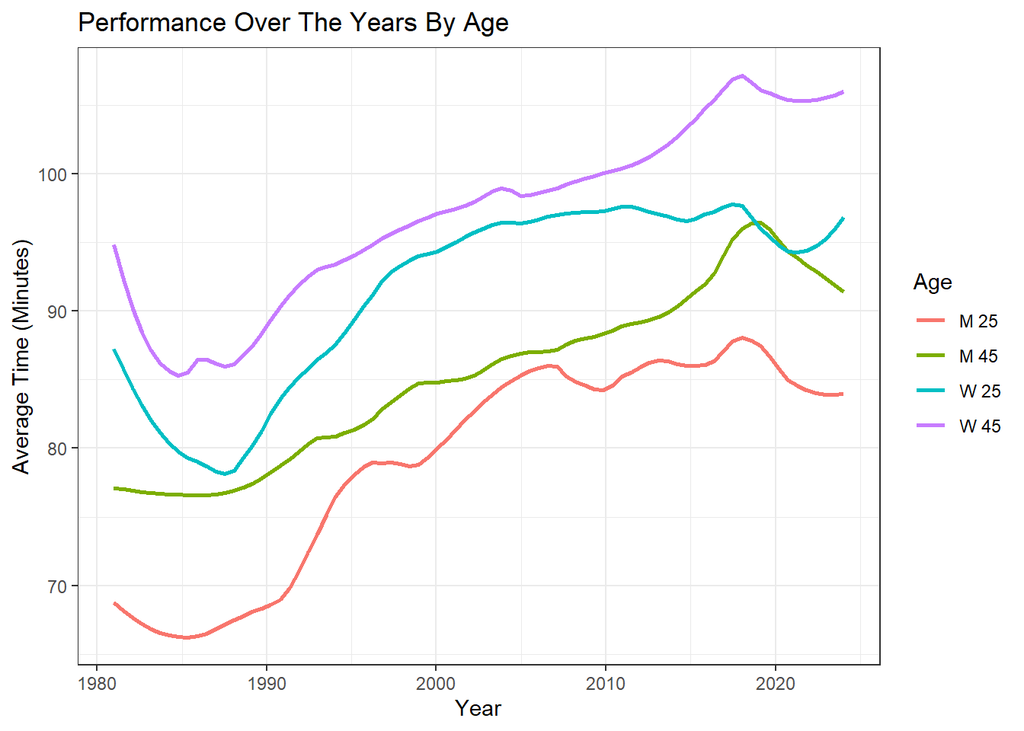

```r
# Filter data for specific age groups and genders
filtered_data <- Dat_Comb.weather %>%
  filter(Age %in% c(25, 45), Gender %in% c("M", "W")) %>%
  mutate(
    Age_Group = paste(Gender, Age, sep = " ")
  )

# Summarize performance (e.g., average time in minutes) by year and age group
performance_by_age <- filtered_data %>%
  group_by(Year, Age_Group) %>%
  summarise(Average_Time = mean(Minutes, na.rm = TRUE), .groups = "drop")

# Plot performance over age with smoothed lines
ggplot(performance_by_age, aes(x = Year, y = Average_Time, color = Age_Group)) +
  geom_smooth(se = FALSE, method = "loess", span=0.25,size = 1) +  # Add smoothed lines
  labs(
    title = "Performance Over The Years By Age",
    x = "Year",
    y = "Average Time (Minutes)",
    color = "Age"
  ) +
  theme_bw()
```

```r
top25 <- Dat_Comb.weather %>%
  group_by(Year, Gender) %>%
  arrange(Minutes) %>%
  slice_head(n = 25) %>%
  ungroup()

# Calculate the mean of the top 25 for each Year and Gender
mean_top25_times <- top25 %>% filter(Gender %in% c("M", "W") ) %>%
  group_by(Year, Gender) %>%
  summarise(mean_minutes = mean(Minutes, na.rm = TRUE)) %>%
  ungroup()
```

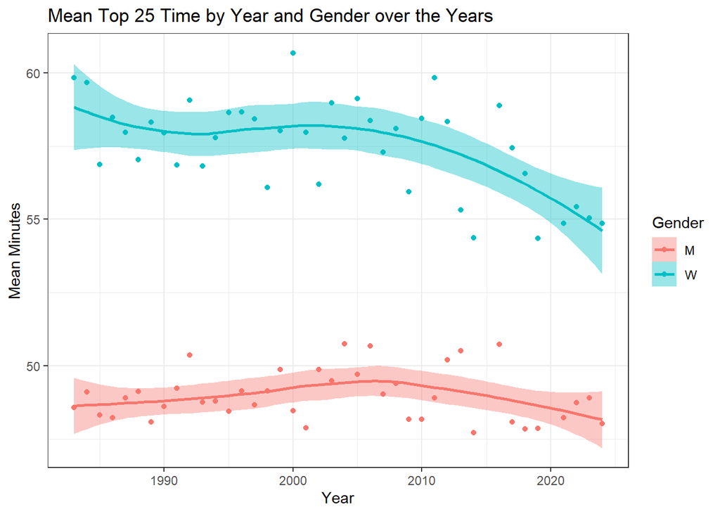

```r
# Filter the data to exclude years before 1983 and specific years 2015 and 2020
filtered_data <- mean_top25_times %>%
  filter(Year > 1982, !Year %in% c(2015, 2020))

ggplot(filtered_data, aes(x = Year, y = mean_minutes, color = Gender)) +
  geom_point() +
  geom_smooth(method = "loess",scale=0.2, se = TRUE, aes(fill = Gender)) +
  labs(
    title = "Mean Top 25 Time by Year and Gender over the Years",
    x = "Year",
    y = "Mean Minutes"
  ) +
  theme_bw()
```